# Principal Components Analysis

## Dimensionality

Let’s start thinking about our data in terms of *dimensions in space*.

Each **predictor** is an **axis**.

The values of the predictors for a certain **observation** define a point in space.

When we compute distances between observations for KNN, we are computing **distance in space**.

When we fit a **regression**, we are drawing a **straight line** through the points.

## The Curse of Dimensionality

We run into trouble when we have **too many dimensions**. But what does “too many” mean?

**Parametric** estimation – We can’t estimate 7000 coefficients from only 44 observations!

**Interpretability** – Do we really want to translate our model into meaning for thousands of predictors???

**Flexibility** – More predictors = more flexibility = overfitting?

## Principal Components Analysis

**PCA** is a way to *transform our data* (prior to modeling!) so that it has fewer **dimensions in space**.

Instead of:

axis 1 = Predictor A

axis 2 = Predictor B

axis 3 = Predictor C

axis 1 = 0.5 (Pred A) + 0.2 (Pred B) + 0.3 (Pred C)

axis 2 = 0.1 (Pred A) + 0.7 (Pred B) + 0.2 (Pred C)

axis 3 = 0.1 (Pred A) + 0.2 (Pred B) + 0.8 (Pred C)

## PCA

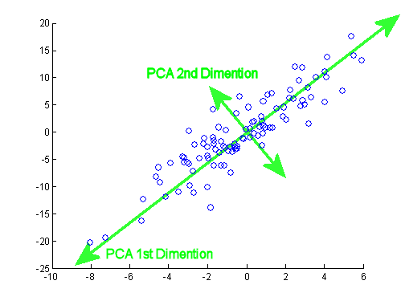

## PCA – In 5 Steps!

1. **Standardize** all axes
2. Find the axis of **highest variance**: This is PC 1
3. Find the axis of **highest variance** that is **perpendicular to PC 1**: This is PC2
4. Continue until you have $p$ PCs, where $p$ = number of predictors (or, if $p > n$, until you have $n$ PCs).
5. Use only the first $k$ predictors in your analysis, where $k < p$ and $k < n$.

## A New Dataset!

The **Federalist papers** are a series of essays written by John Jay, Alexander Hamilton, and James Madison.

```
Rows: 85
Columns: 71
$ Author <chr> "AH", "JJ", "JJ", "JJ", "JJ", "AH", "AH", "AH", "AH", "JM", "AH…
$ a      <dbl> 0.015704, 0.017365, 0.008990, 0.009780, 0.006691, 0.024140, 0.0…
$ do     <dbl> 0.0006281, 0.0000000, 0.0006916, 0.0012225, 0.0000000, 0.000000…
$ is     <dbl> 0.007538, 0.009581, 0.004841, 0.006112, 0.005204, 0.004109, 0.0…
$ or     <dbl> 0.003769, 0.005988, 0.022130, 0.014670, 0.007435, 0.009759, 0.0…
$ this   <dbl> 0.0087940, 0.0083832, 0.0041494, 0.0006112, 0.0044610, 0.005649…
$ all    <dbl> 0.005653, 0.002395, 0.002766, 0.002445, 0.002974, 0.002568, 0.0…
$ down   <dbl> 0.0000000, 0.0000000, 0.0000000, 0.0000000, 0.0000000, 0.000000…
$ it     <dbl> 0.012563, 0.022754, 0.014523, 0.017115, 0.015613, 0.005650, 0.0…
$ our    <dbl> 0.0018844, 0.0023952, 0.0000000, 0.0110024, 0.0052045, 0.002054…
$ to     <dbl> 0.04460, 0.03174, 0.03873, 0.03117, 0.03346, 0.02928, 0.03586, …
$ also   <dbl> 0.0000000, 0.0011976, 0.0020747, 0.0012225, 0.0014870, 0.000000…
$ even   <dbl> 0.0012563, 0.0000000, 0.0006916, 0.0000000, 0.0014870, 0.000000…
```

[output cut: 58 more lines]

## Authors and Word Selection

If we choose a couple words and plot our data…

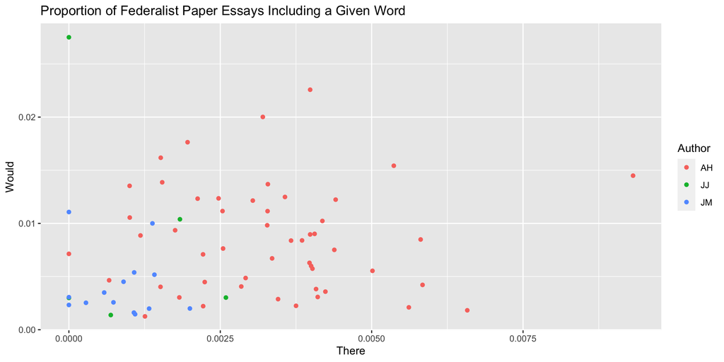

## Let’s Give PCA a Try Instead!

```r
fed_matrix <- fed_known %>%
  select(-Author)

pc <- prcomp(fed_matrix,
             center = TRUE,
             scale = TRUE)
```

## Previewing the Principal Components

```
              PC1        PC2        PC3        PC4        PC5       PC6
a       0.1981759 -0.0007576  0.0935479 -0.1214028 -0.1896307  0.072464
do     -0.0302646 -0.0727378 -0.0926549 -0.0626465 -0.1555949  0.036756
is      0.1336907  0.0797518 -0.1785689  0.0632460 -0.1423981 -0.053693
or     -0.1089584 -0.1039416 -0.0132435  0.0042732  0.0412992 -0.177685
this    0.2334027  0.0630079 -0.0218351 -0.0906833 -0.1114024  0.034180
all     0.0844019  0.0628760  0.0426171  0.1138584  0.1803859 -0.052679
down    0.0292295 -0.0751349 -0.0179187  0.0165084  0.0005723 -0.140894
it     -0.0292278 -0.0288241 -0.2022608 -0.2491168  0.0007965  0.065907
our    -0.1253024 -0.0447230  0.0946293 -0.0059994  0.1822235 -0.004053
to      0.1133667 -0.1822340 -0.0075929 -0.1504039  0.1180770  0.042107
also   -0.1895352  0.0803221  0.0144453  0.1038795 -0.2159480 -0.021350
even    0.0412006 -0.0053735  0.1988205 -0.1080156 -0.0070907 -0.085335
its     0.0925980 -0.1364080 -0.1003783  0.0562824  0.1573799 -0.087837
shall   0.0275950  0.0069202 -0.0851937  0.0941129 -0.2189935  0.061184
up      0.0440077 -0.0079942  0.1198425 -0.1167414  0.0746236 -0.092781
an      0.1987379  0.0008641  0.0911709 -0.1070558 -0.0145571  0.066112
every   0.1006472  0.0201706 -0.1635864  0.1268195 -0.1723828 -0.016974
may    -0.0002659 -0.1579650 -0.1937055  0.0956668 -0.1181080  0.055328
should -0.0633278  0.0130290 -0.0238200 -0.2547560  0.0931800 -0.055491
upon    0.2414271 -0.1504749  0.0467621 -0.1254395  0.0574721  0.071282
and    -0.2969149  0.0829995 -0.0079523  0.0648104  0.1141941 -0.069459
for.   -0.0157047  0.0162808 -0.0724953 -0.1430258  0.1098381  0.248564
more   -0.2192323 -0.1299366  0.1103656  0.1446700  0.0100714  0.140034
so     -0.1086778  0.1128618 -0.0066667 -0.0998796 -0.0727491  0.083290
was    -0.0715233  0.1842704  0.0885424 -0.1669124  0.0237832  0.081902
any     0.0787914 -0.1654147 -0.1948456 -0.0904529 -0.0979459  0.115191
from   -0.0538480 -0.0855730 -0.0189852 -0.0800935 -0.0208899 -0.010870
must    0.0699937 -0.0614886 -0.0847015  0.0259458  0.1243413 -0.066070
some   -0.0402275  0.1677606  0.0205801 -0.1322933  0.0800816  0.040848
were   -0.0881025  0.2133738  0.1631943 -0.0913072 -0.0243510  0.020300
are    -0.0289084 -0.0054206 -0.1499528  0.1468966  0.2067623 -0.071900
had    -0.0324871  0.2425797  0.1570041 -0.1313018  0.0193986 -0.007653
my      0.0233205 -0.0356503 -0.0390196  0.1464615  0.1567600  0.371588
such   -0.1173833 -0.0401929 -0.1668267 -0.1785828 -0.0693765 -0.136333
what    0.0172092 -0.0705219 -0.0636006 -0.1675140  0.0503963 -0.117523
as     -0.0948436  0.0130255 -0.1839922 -0.0586473  0.0603872 -0.110436
has     0.1050669  0.1710242  0.0006227  0.0828899 -0.0450030  0.178949
no      0.0804094  0.0264551 -0.1455691  0.1405018 -0.2332574  0.012766
than   -0.1292803 -0.2098651  0.0407369  0.1246189 -0.1711510  0.261084
```

[output cut: 726 more lines]

```
but    -0.253663 -0.026527  0.083378 -0.046834 -0.162178
if.    -0.043932 -0.121840 -0.015017 -0.100369 -0.074855
on      0.152072  0.023887 -0.059072  0.242858 -0.186111
then    0.184225  0.005547  0.134690 -0.046577 -0.022830
with   -0.100088  0.010708  0.062755  0.186886  0.003541
by     -0.031198 -0.152468  0.099569 -0.042787 -0.123959
in.    -0.129682 -0.003243 -0.088538  0.166303 -0.038703
one     0.090683  0.103785  0.037113 -0.213917  0.117059
there   0.088650 -0.092545  0.170686  0.070754  0.223355
would   0.251680  0.053636  0.178016  0.143985 -0.115817
can    -0.082819 -0.025017 -0.208588  0.019387 -0.085710
into    0.128204  0.086563  0.140106  0.056567  0.021951
only   -0.046854 -0.005802  0.216070  0.035056  0.183114
things -0.023549  0.143274  0.098084 -0.085179  0.119426
your   -0.073293  0.144155  0.098543 -0.208878 -0.001796
```

## What variables matter most?

```
          PC1        PC2        PC3        PC4        PC5
1  -0.2969149  0.0829995 -0.0079523  0.0648104  0.1141941
2   0.2532369  0.0465962  0.1820845  0.0849970 -0.0677631
3   0.2414271 -0.1504749  0.0467621 -0.1254395  0.0574721
4   0.2334027  0.0630079 -0.0218351 -0.0906833 -0.1114024
5  -0.2310547 -0.0273376  0.0517796  0.0560865 -0.2252644
6  -0.2192323 -0.1299366  0.1103656  0.1446700  0.0100714
7  -0.2098190  0.0526373 -0.0558632 -0.1481704  0.1857935
8   0.1987379  0.0008641  0.0911709 -0.1070558 -0.0145571
9   0.1981759 -0.0007576  0.0935479 -0.1214028 -0.1896307
10  0.1959157  0.0652826 -0.0653657  0.0971773 -0.0635347
11 -0.1895352  0.0803221  0.0144453  0.1038795 -0.2159480
12 -0.1646578 -0.0768915  0.0947230  0.1017412 -0.0845516
13  0.1570871 -0.2135796  0.0912550 -0.0034868 -0.0925714
14  0.1517917  0.0252016 -0.0993965 -0.1591765 -0.1155705
```

[output cut: 56 more lines]

How can we use our principal components to help us visualize the data?

## Locations of Observations on New (PC) Axes

```
          PC1      PC2      PC3      PC4       PC5
1    0.255883 -2.75723 -0.84061  4.22604  3.580825
2   -5.333328  4.41925  0.10285 -1.85960  0.385100
3   -7.933306 -1.90187 -2.06613  0.17152  0.444284
4  -10.132733 -3.01485 -0.76659  0.22149  0.388497
5   -8.922169 -2.22472  3.78289 -0.08058 -0.187915
6   -0.664084  3.30507  3.19383  1.00454  1.497993
7    1.140376  1.88974  5.25083 -1.66296  1.699322
8    0.358401  1.23172  2.36159  0.81826  1.955048
9    0.140885  4.29456  2.16608  0.56263 -0.004672
10  -2.035723 -0.31634 -1.02594  1.82065  1.242992
11  -0.637666 -1.45658  3.78830  0.35541 -0.251304
12   1.392538 -0.17138  1.80856  1.19238  1.713521
13  -2.132165 -6.97474  4.04474  4.79525 -6.312285
14  -1.017369  1.67820 -1.35167  2.20414  2.951174
```

[output cut: 56 more lines]

## Plotting the First Two Principal Components

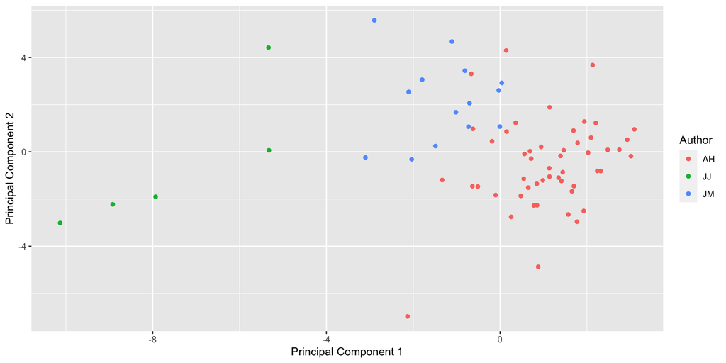

## Standard Deviations of PC Scores

```
 [1] 2.584293976481499833 2.224602605692585389 2.133495077907519022
 [4] 2.009679212438627793 1.771199010414047370 1.737846153429810192
 [7] 1.658192994671915832 1.593432897204485554 1.567765465416048887
[10] 1.498153968179445794 1.448627829241020182 1.383202255873344555
[13] 1.348835290469533765 1.329864883494041417 1.290075723747527325
[16] 1.263656822413196323 1.211546834748383539 1.179468039028208404
[19] 1.140273064226865030 1.136685249904107131 1.091881595973659413
[22] 1.024359742653421224 1.002539216556411539 0.988309265374063162
[25] 0.966758063464952966 0.953955378557446720 0.913371285706331304
[28] 0.879219144916352224 0.866397791514435633 0.835362796306243993
[31] 0.813744862497517873 0.795836559214300299 0.777288905706550293
[34] 0.755507991799209022 0.729325759585313538 0.723553021174748068
[37] 0.668529227774796064 0.644640218695885947 0.608063670676834311
[40] 0.599862980594791928 0.589869259793525336 0.549984140873157168
[43] 0.518576401942239085 0.490365964788198327 0.485951132126855978
[46] 0.473420966039043101 0.447648096786177674 0.410247671033033112
[49] 0.398219462937035862 0.381729038085061256 0.356072979106936749
[52] 0.322926868470927664 0.302289519970545317 0.278418759166978558
[55] 0.254888335158211798 0.246279930847948220 0.227060020169778415
[58] 0.209288942626959018 0.201384112256443870 0.181411412891078483
[61] 0.162645660545995274 0.152090980040968937 0.125916504292499898
[64] 0.109322167263386394 0.082184427523103967 0.065913614423482467
[67] 0.042908983610013510 0.042409262279552391 0.016148272444814281
[70] 0.000000000000001144
```

What do you notice???

## Cumulative Variances

```
 [1] 0.09541 0.16611 0.23113 0.28883 0.33365 0.37679 0.41607 0.45234 0.48745
[10] 0.51952 0.54950 0.57683 0.60282 0.62809 0.65186 0.67467 0.69564 0.71552
[19] 0.73409 0.75255 0.76958 0.78457 0.79893 0.81288 0.82623 0.83923 0.85115
[28] 0.86219 0.87292 0.88289 0.89235 0.90139 0.91003 0.91818 0.92578 0.93326
[37] 0.93964 0.94558 0.95086 0.95600 0.96097 0.96529 0.96914 0.97257 0.97594
[46] 0.97915 0.98201 0.98441 0.98668 0.98876 0.99057 0.99206 0.99337 0.99447
[55] 0.99540 0.99627 0.99700 0.99763 0.99821 0.99868 0.99906 0.99939 0.99961
[64] 0.99979 0.99988 0.99994 0.99997 1.00000 1.00000 1.00000
```

How many principal components do we need to explain 85% of the variability in the data?

## A Cumulative Variance Plot

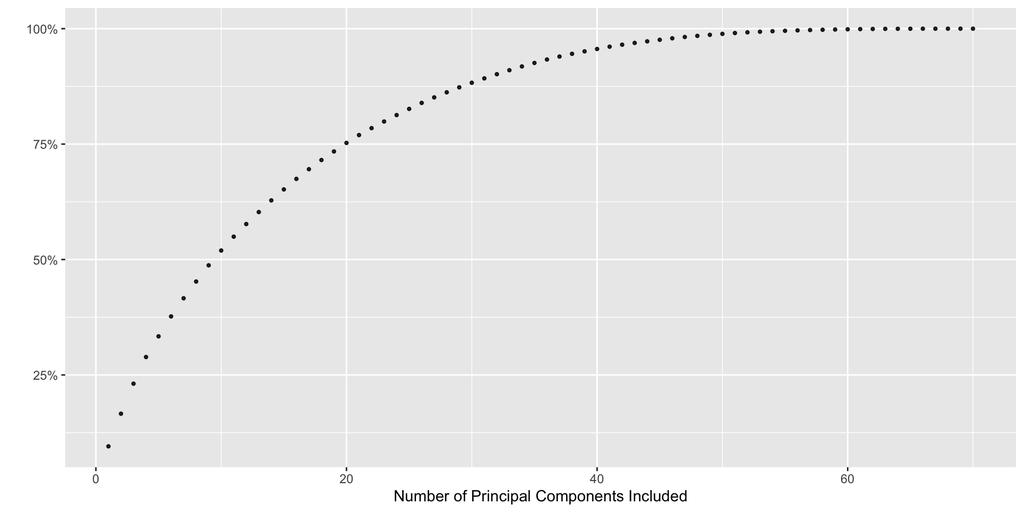

## Some General Questions about Using PCA

**How many PCs should we use?**

No single answer; people often do “enough for 90% variance covered” or similar.

**How do you do modeling with PCA?**

You don’t. It’s a data *preprocessing* step. You would then use `PC1`, `PC2`, etc **instead of** your original predictors.

Or you might use the variable importance measures to help decide which predictors to keep.

## Perks of PCA

**Pros:**

- Reduces dimension while still letting all original predictors be “involved”
- Computationally fast for big data
- Axis rotations are interpretable!
- Dropping off lower PCs gets rid of noise (maybe)

**Cons:**

- Using PCs in interpretable models makes them uninterpretable – what does the coefficient of PC1 mean in real life?
- No magic answer for how many PCs to use.
- Dropping off lower PCs gets rid of useful info (maybe)

## But wait - isn’t this LDA?

Recall that **LDA** also found *scores* for your observations based on a *linear combination* of the original predictors.

So what’s the difference?

LDA loadings are trying to maximize the **difference in mean scores across categories**.

This is a *supervised* method!

PCA loadings are trying to maximize the **variance of the scores** on the PC axes.

This is an *unsupervised* method!

## Try it!

Download and open `Activity-PCA.qmd`

1. Apply PCA to the cannabis data
2. Interpret the PC rotations
3. Plot the data on the first two axes, and color by Type.
4. Choose a “good” number of PCs to use.
5. Fit a KNN classifier using:
- All the variables
- Only the 5 most important variables according to PCA
- Only your chosen PCs
6. Compare the accuracy of these three approaches!